# Prediction Assignment Writeup

# Human Activity Recognition

## Executive Summary

To predict what exercise was performed based upon wearable tech data. Data obtained from http://groupware.les.inf.puc-rio.br/har

The following analysis was conducted…

- Get and clean the data: download, read and process
- Explore the data: find useful parameters
- Model development: extract, apply, and assess knowledge
- Conclusion: based on the data and analysis

## Get the data

Download and read in the data.

```r
# URLs
train.url <- "https://d396qusza40orc.cloudfront.net/predmachlearn/pml-training.csv"
test.url <- "https://d396qusza40orc.cloudfront.net/predmachlearn/pml-testing.csv"

# File names
train.name <- "./data/pml-training.csv"
test.name <- "./data/pml-testing.csv"

# If non-existent create
if (!file.exists("./data")) {
  dir.create("./data")
}

# If non-existent download
if (!file.exists(train.name)) {
  download.file(train.url, destfile = train.name, method="curl")
}
if (!file.exists(test.name)) {
  download.file(test.url, destfile = test.name, method="curl")
}

# Load the data
train <- read.csv("./data/pml-training.csv")
test <- read.csv("./data/pml-testing.csv")
```

## Clean the data

Process the data.

```r
# Inspect the data
# str(train)
# names(train)

# Identify prediction target
target.ori <- train[, "classe"]
target <- target.ori
# levels(target)

# Set character levels as numeric
num.class <- length(levels(target))
levels(target) <- 1:num.class
# head(target)

# Set prediction target as NULL (MLNB. t-Distributed Stochastic Neighbor Embedding)
train$classe <- NULL

# Select belt, forearm, arm, and dumbell variables (as per assignment instructions)
select <- grepl("belt|arm|dumbell", names(train))
train <- train[, select]
test <- test[, select]

# Clean the data by removing NAs (MLNB. t-Distributed Stochastic Neighbor Embedding)
cols.without.na <- colSums(is.na(test)) == 0
train <- train[, cols.without.na]
test <- test[, cols.without.na]
```

## Explaoratory analysis

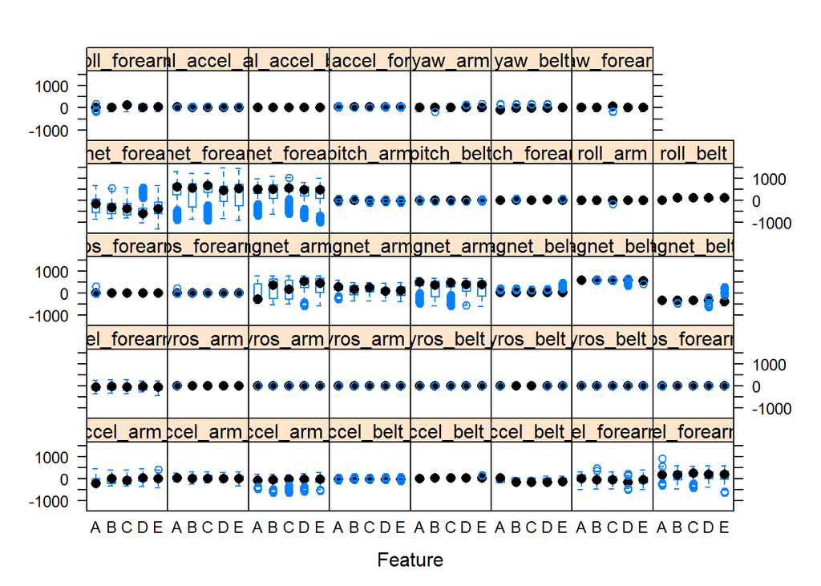

```r
# Check for zero variance
zero.var <- nearZeroVar(train, saveMetrics = TRUE)
# zero.var

# Correlation between features and the prediction target
featurePlot(train, target.ori, "box")
```

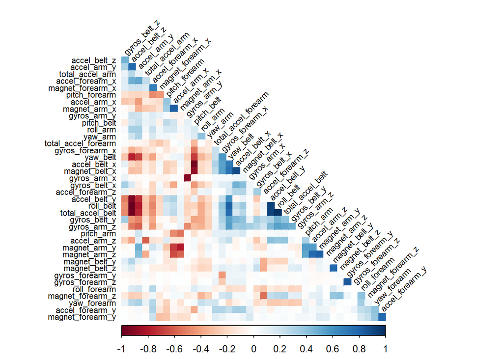

```r
corrplot(cor(train), method = "color", type = "lower", order = "hclust", tl.cex = 0.70, tl.col="black", tl.srt = 45, diag = FALSE)
```

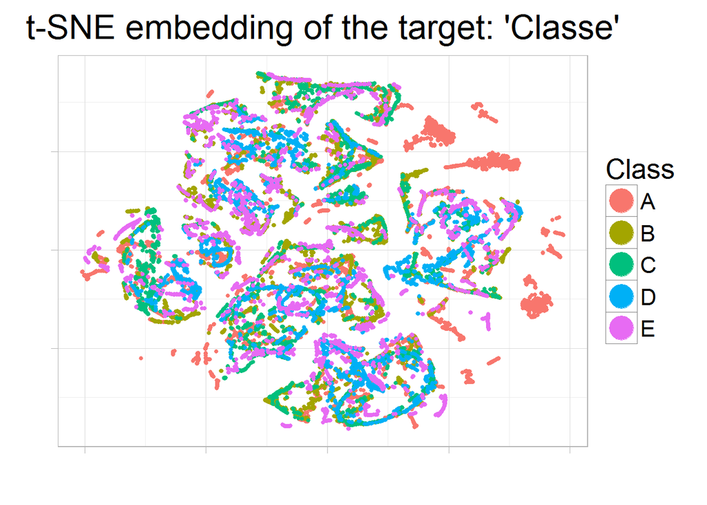

```r
# The t-Distributed Stochastic Neighbor Embedding method
tDSNE <- Rtsne(as.matrix(train), check_duplicates = FALSE, pca = TRUE, perplexity = 50, theta = 0.25, dims = 2)
embedding <- as.data.frame(tDSNE$Y)
embedding$Class <- target.ori
fig <- ggplot(embedding, aes(x = V1, y = V2, color = Class)) +
  geom_point(size = 1) +
  guides(colour = guide_legend(override.aes = list(size = 8))) +
  xlab("") +
  ylab("") +
  ggtitle(" t-SNE embedding of the target: 'Classe' ") +
  theme_light(base_size = 20) +
  theme(axis.text.x = element_blank(), axis.text.y = element_blank())
print(fig)
```

t-SNE is a (prize-winning) technique for dimensionality reduction that is particularly well suited for the visualization of high-dimensional datasets (implemented via Barnes-Hut approximations).

## Model development

### Prepare the data

The extreme gradient boosting tree method requires numeric matrix data.https://cran.r-project.org/web/packages/xgboost/

```r
# Format train dataset as a matrix and set as numeric
Mtrain <- as.matrix(train)
mode(Mtrain) = "numeric"

# Format test dataset as a matrix and set as numeric
Mtest = as.matrix(test)
mode(Mtest) = "numeric"

# Set target dataset as numeric
y <- as.matrix(as.integer(target)-1)
```

### Train, cross-validate, and evaluate the model

Set the parameters for training and cross validation, as well as setting a multiple classification objective as the learning function. Evaluate with merror, confusion matrix, and test data.

```r
# xgboost parameters
xgbp <- list("objective" = "multi:softprob", "num_class" = num.class, "eval_metric" = "merror", "nthread" = 8, "max_depth" = 16, "eta" = 0.3, "gamma" = 0, "subsample" = 1, "colsample_bytree" = 1, "min_child_weight" = 12 )

# Set the seed
set.seed(4567)

# Timed k-fold cross validation
system.time( bst.cv <- xgb.cv(param = xgbp, data = Mtrain, label = y, nfold = 5, nrounds = 100, prediction = TRUE, verbose = FALSE) )
```

```
##    user  system elapsed
##  425.35   13.54  119.53
```

```r
# head(bst.cv$dt)
# tail(bst.cv$dt)

# Index of minimum merror
min.merror.idx <- which.min(bst.cv$dt[, test.merror.mean])
# min.merror.idx

# Minimum merror
bst.cv$dt[min.merror.idx,]
```

```
##    train.merror.mean train.merror.std test.merror.mean test.merror.std
## 1:                 0                0         0.005504        0.001987
```

```r
# Prediction decoding
pred.cv <- matrix(bst.cv$pred, nrow = length(bst.cv$pred)/num.class, ncol = num.class)
pred.cv <- max.col(pred.cv, "last")

# Confusion matrix
confusionMatrix(factor(y+1), factor(pred.cv))
```

```
## Confusion Matrix and Statistics
##
##           Reference
## Prediction    1    2    3    4    5
##          1 5570    4    4    2    0
##          2    8 3770   19    0    0
##          3    0   27 3380   15    0
##          4    0    1   21 3191    3
##          5    0    1    1    4 3601
##
## Overall Statistics
##
##                Accuracy : 0.9944
##                  95% CI : (0.9932, 0.9954)
##     No Information Rate : 0.2843
##     P-Value [Acc > NIR] : < 2.2e-16
##
##                   Kappa : 0.9929
##  Mcnemar's Test P-Value : NA
##
## Statistics by Class:
##
##                      Class: 1 Class: 2 Class: 3 Class: 4 Class: 5
## Sensitivity            0.9986   0.9913   0.9869   0.9935   0.9992
## Specificity            0.9993   0.9983   0.9974   0.9985   0.9996
## Pos Pred Value         0.9982   0.9929   0.9877   0.9922   0.9983
## Neg Pred Value         0.9994   0.9979   0.9972   0.9987   0.9998
## Prevalence             0.2843   0.1938   0.1745   0.1637   0.1837
## Detection Rate         0.2839   0.1921   0.1723   0.1626   0.1835
## Detection Prevalence   0.2844   0.1935   0.1744   0.1639   0.1838
## Balanced Accuracy      0.9989   0.9948   0.9921   0.9960   0.9994
```

```r
# Model fit
system.time( bst <- xgboost(param = xgbp, data = Mtrain, label = y, nrounds = min.merror.idx, verbose = FALSE) )
```

```
##    user  system elapsed
##   89.35    2.43   24.28
```

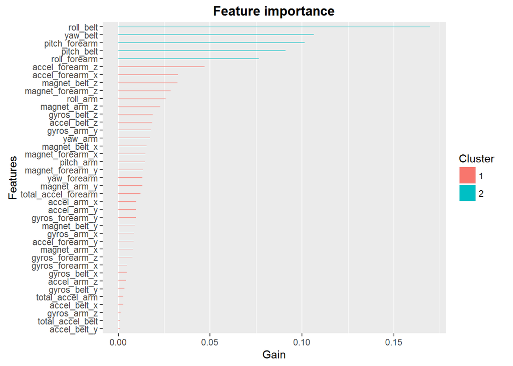

```r
# xgboost predict test data using the trained model
pred <- predict(bst, Mtest)
# head(pred, 10)

# Prediction set as character
pred <- matrix(pred, nrow = num.class, ncol = length(pred)/num.class)
pred <- t(pred)
pred <- max.col(pred, "last")
pred.char <- toupper(letters[pred])

# Get the trained model
model <- xgb.dump(bst, with.stats = TRUE)

# Get the feature real names
names <- dimnames(Mtrain)[[2]]

# Compute feature importance matrix
importance_matrix <- xgb.importance(names, model = bst)

# Plot
gp <- xgb.plot.importance(importance_matrix)
print(gp)
```

### Write output

Print out and write to file the predictions.

```r
# Print
pred.char
```

```
##  [1] "B" "A" "B" "A" "A" "E" "D" "B" "A" "A" "B" "C" "B" "A" "E" "E" "A"
## [18] "B" "B" "B"
```

```r
path = "./data/"
pml_write_files = function(x) {
  n = length(x)
  for(i in 1: n) {
    filename = paste0("problem_id_", i, ".txt")
    write.table(x[i], file=file.path(path, filename),
                quote=FALSE, row.names=FALSE, col.names=FALSE)
  }
}
pml_write_files(pred.char)
```

## Conclusion

The confusion matrix of the xgb-model (5-fold cross validation with 100 cycles) shows an overall accuracy of ~ 99.5%. Computational analysis completed with an elapsed time ~ 2mins. To potentially improve the model (both in terms of computation time and reduce possible overfitting), low ranking features may be removed (cluster 1).